# Benthos Indices: Results

2025-11-13

Script below copied from https://github.com/NOAA-EDAB/benthosindex/blob/main/Results.Rmd

# Introduction

Models for macrobenthos and megabenthos were run for spring and fall using all spatial and spatio-temporal random effects, and three catchability covariates: mean predator length at the location, number of predator species at the location, and bottom temperature at the location.

# Methods

See [workflow document](https://noaa-edab.github.io/benthosindex/WorkflowDecisions.html) for details.

# Results

## Counts of stations total and with prey

In the table below, Total stations is all stations where benthivore predators were sampled. The fields from Total stomachs through Variance n preds reflect the number of predators sampled at all of these stations. The last four columns reflect the number and percent of stations with positive macrobenthos and megabenthos prey, respectively.

Note that we did not use data from 1973-1979 in the models. As of October 2024, we are including data through 2023 from both NEFSC and NEAMAP.

```r
macrobenagg_stn <- readRDS(here::here("benthos/fhdata/macrobenagg_stn_all_modBT.rds"))
megabenagg_stn <- readRDS(here::here("benthos/fhdata/megabenagg_stn_all_modBT.rds"))

nstationsyr <- macrobenagg_stn |>
  dplyr::group_by(year, season_ng) |>
  dplyr::summarise(totstations = n(),
                   totstomachs = sum(nstomtot),
                   minnpred = min(nbenthivoresp),
                   meannpred = mean(nbenthivoresp),
                   maxnpred = max(nbenthivoresp),
                   varnpred = var(nbenthivoresp))

macropreystns <- macrobenagg_stn |>
  dplyr::filter(meanmacrobenpywt > 0) |>
  dplyr::group_by(year, season_ng) |>
  dplyr::summarise(macrobenstations = n())

megapreystns <- megabenagg_stn |>
  dplyr::filter(meanmegabenpywt > 0) |>
  dplyr::group_by(year, season_ng) |>
  dplyr::summarise(megabenstations = n())

stationsprey <- dplyr::left_join(nstationsyr, macropreystns) |>
  dplyr::left_join(megapreystns) |>
  dplyr::arrange(desc(season_ng), .by_group = TRUE) |>
  dplyr::mutate(year = as.character(year),
                percmacro = round(macrobenstations/totstations*100),
                percmega = round(megabenstations/totstations*100)) |>
  na.omit()

flextable::flextable(stationsprey) |>
  flextable::colformat_char(j = "year") |>
  flextable::fontsize(size = 8, part = "all") |>
  flextable::set_header_labels(
    year = "Year", season_ng = "Season", totstations = "Total stations",
    totstomachs = "Total stomachs", minnpred = "Minimum n preds", meannpred = "Mean n preds",
    maxnpred = "Maximum n preds", varnpred = "Variance n preds",
    macrobenstations =  "Macrobenthos stations",
    megabenstations = "Megabenthos stations",
    percmacro =  "Percent macrobenthos", percmega = "Percent megabenthos")
```

| Year | Season | Total stations | Total stomachs | Minimum n preds | Mean n preds | Maximum n preds | Variance n preds | Macrobenthos stations | Megabenthos stations | Percent macrobenthos | Percent megabenthos |
| --- | --- | --- | --- | --- | --- | --- | --- | --- | --- | --- | --- |
| 1973 | SPRING | 148 | 1,437 | 1 | 1.655405 | 5 | 0.7443924 | 110 | 35 | 74 | 24 |
| 1973 | FALL | 183 | 2,493 | 1 | 2.142077 | 6 | 1.4522308 | 151 | 61 | 83 | 33 |
| 1974 | SPRING | 165 | 1,972 | 1 | 2.018182 | 5 | 1.3106430 | 126 | 70 | 76 | 42 |
| 1974 | FALL | 186 | 1,886 | 1 | 1.838710 | 6 | 1.1630340 | 149 | 57 | 80 | 31 |
| 1975 | SPRING | 34 | 328 | 1 | 1.500000 | 5 | 0.8030303 | 27 | 17 | 79 | 50 |
| 1975 | FALL | 162 | 1,812 | 1 | 1.864198 | 5 | 1.0000767 | 135 | 51 | 83 | 31 |
| 1976 | SPRING | 182 | 2,183 | 1 | 2.076923 | 5 | 1.6404590 | 152 | 49 | 84 | 27 |
| 1976 | FALL | 163 | 2,105 | 1 | 2.024540 | 6 | 1.3203817 | 132 | 66 | 81 | 40 |
| 1977 | SPRING | 217 | 2,591 | 1 | 2.552995 | 7 | 2.5446322 | 165 | 68 | 76 | 31 |
| 1977 | FALL | 232 | 2,395 | 1 | 2.043103 | 8 | 2.0500821 | 162 | 93 | 70 | 40 |
| 1978 | SPRING | 271 | 2,887 | 1 | 2.081181 | 11 | 2.1785705 | 187 | 75 | 69 | 28 |
| 1978 | FALL | 495 | 5,372 | 1 | 2.115152 | 8 | 2.1871181 | 334 | 185 | 67 | 37 |
| 1979 | SPRING | 294 | 2,377 | 1 | 1.880952 | 7 | 1.1837315 | 199 | 79 | 68 | 27 |
| 1979 | FALL | 545 | 5,999 | 1 | 2.137615 | 10 | 2.1666892 | 351 | 214 | 64 | 39 |
| 1980 | SPRING | 269 | 2,466 | 1 | 1.836431 | 6 | 1.1373245 | 171 | 75 | 64 | 28 |
| 1980 | FALL | 367 | 3,844 | 1 | 2.013624 | 10 | 1.6254969 | 233 | 113 | 63 | 31 |
| 1981 | SPRING | 262 | 3,246 | 1 | 1.793893 | 5 | 0.8539089 | 144 | 113 | 55 | 43 |
| 1981 | FALL | 230 | 2,801 | 1 | 1.700000 | 6 | 0.9532751 | 96 | 72 | 42 | 31 |
| 1982 | SPRING | 372 | 4,988 | 1 | 2.190860 | 10 | 2.3812639 | 234 | 104 | 63 | 28 |
| 1982 | FALL | 231 | 2,210 | 1 | 1.865801 | 6 | 1.1775645 | 87 | 57 | 38 | 25 |
| 1983 | SPRING | 297 | 2,455 | 1 | 1.666667 | 7 | 0.9662162 | 110 | 65 | 37 | 22 |
| 1983 | FALL | 206 | 1,736 | 1 | 1.728155 | 5 | 0.9111058 | 64 | 41 | 31 | 20 |
| 1984 | SPRING | 309 | 2,312 | 1 | 1.394822 | 5 | 0.4929601 | 135 | 74 | 44 | 24 |
| 1984 | FALL | 255 | 2,604 | 1 | 1.956863 | 7 | 1.5375019 | 106 | 69 | 42 | 27 |
| 1985 | SPRING | 314 | 6,213 | 1 | 3.098726 | 9 | 3.7506054 | 201 | 118 | 64 | 38 |
| 1985 | FALL | 250 | 4,377 | 1 | 2.980000 | 9 | 3.3690763 | 104 | 80 | 42 | 32 |
| 1986 | SPRING | 311 | 5,871 | 1 | 3.395498 | 9 | 3.2979152 | 191 | 121 | 61 | 39 |
| 1986 | FALL | 249 | 4,112 | 1 | 3.116466 | 12 | 4.2807358 | 132 | 119 | 53 | 48 |
| 1987 | SPRING | 304 | 5,711 | 1 | 3.483553 | 10 | 3.3264613 | 234 | 145 | 77 | 48 |
| 1987 | FALL | 269 | 3,909 | 1 | 2.762082 | 8 | 2.5551240 | 148 | 109 | 55 | 41 |

[output cut: 74 more lines]

## Spatial distribution of stations

```r
# from each output folder in pyindex,
outdir <- here::here("benthos/pyindex")
moddirs <- list.dirs(outdir)
moddirs <- moddirs[-1]

# only latest
moddirs23 <- moddirs[grep("1980-2024", moddirs, invert = TRUE)]
```

Spatial coverage for stomachs in fall, both groups (same set of predators, same stations)

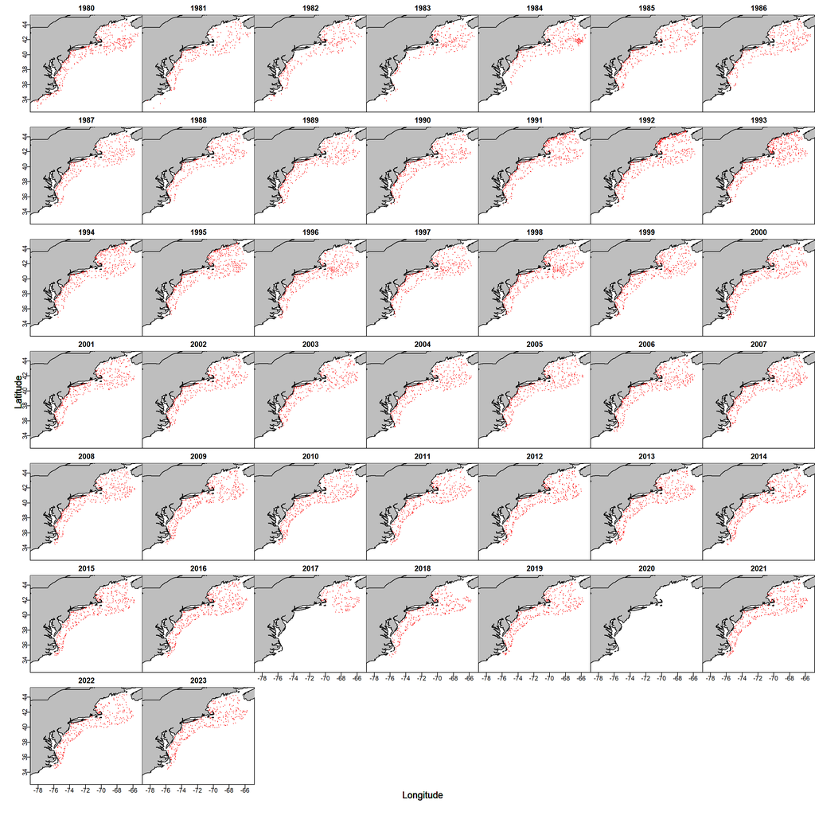

```r
mapfall <- paste0(moddirs23[1], "/Data_by_year.png")

knitr::include_graphics(mapfall)
```

Spatial coverage for stomachs in spring, both groups (same set of predators, same stations)

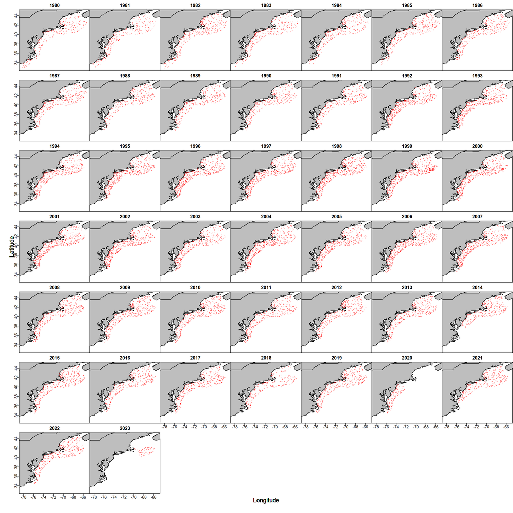

```r
mapspring <- paste0(moddirs23[2], "/Data_by_year.png")

knitr::include_graphics(mapspring)
```

## Model selection

See [workflow document](https://noaa-edab.github.io/benthosindex/WorkflowDecisions.html) for details.

## Model results

```r
stratlook <- data.frame(Stratum = c("Stratum_1",
                                    "Stratum_2",
                                    "Stratum_3",
                                    "Stratum_4",
                                    "Stratum_5"),
                        Region  = c("AllEPU",
                                    "MAB",
                                    "GB",
                                    "GOM",
                                    "SS"))
```

```r
# function to apply extracting info
getmodindex <- function(d.name){
  # read settings
  modpath <- stringr::str_split(d.name, "/", simplify = TRUE)
  modname <- modpath[length(modpath)]

  index <- read.csv(file.path(d.name, "Index.csv"))
  # return model indices as a dataframe
  out <- data.frame(modname = modname,
                    index
  )

  return(out)
}

modcompareindex <- purrr::map_dfr(moddirs23, getmodindex)
```

```r
splitoutput <- modcompareindex %>%
  dplyr::mutate(Season = modname |> map(str_split, pattern = "_") |> map_chr(c(1,2))) %>%
  dplyr::mutate(Data = modname |> map(str_split, pattern = "_") |> map_chr(c(1,1))) %>%
  dplyr::left_join(stratlook) %>%
  dplyr::filter(Region %in% c("GOM", "GB", "MAB","SS", "AllEPU"))

benthosmax <- max(splitoutput$Estimate)


benthostsmean <- splitoutput %>%
  dplyr::group_by(modname, Region) %>%
  dplyr::mutate(fmean = mean(Estimate))
```

Do we have `ecodata` trends in any time series? Some. Driven by early 80s spike?

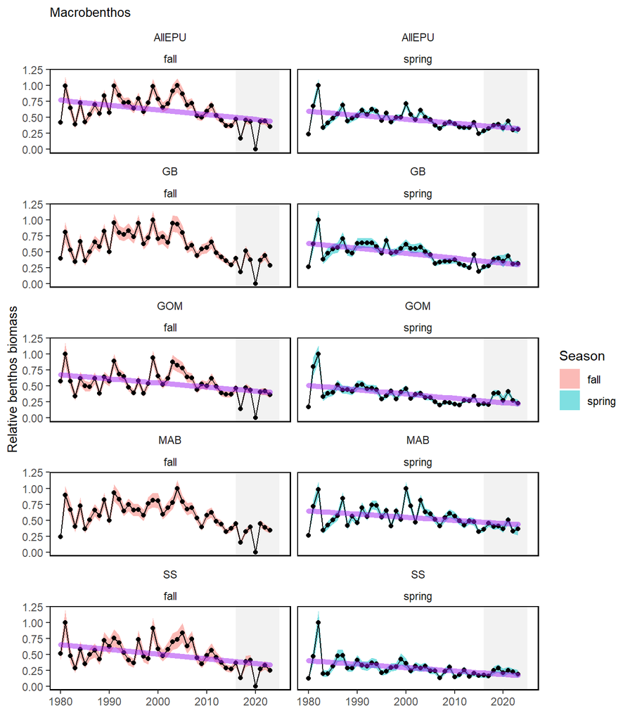

```r
filterEPUs <- c("MAB", "GB", "GOM", "SS", "AllEPU")

currentMonth <- lubridate::month(Sys.Date())
    currentYear <- lubridate::year(Sys.Date())
    if (currentMonth > 4) {
      endShade <- currentYear
    } else {
      endShade <- currentYear - 1
    }
    shadedRegion <- c(endShade-9,endShade)

    shade.alpha <- 0.3
    shade.fill <- "lightgrey"
    lwd <- 1
    pcex <- 2
    trend.alpha <- 0.5
    trend.size <- 2
    hline.size <- 1
    line.size <- 2
    hline.alpha <- 0.35
    hline.lty <- "dashed"
    label.size <- 5
    hjust.label <- 1.5
    letter_size <- 4
    errorbar.width <- 0.25
    x.shade.min <- shadedRegion[1]
    x.shade.max <- shadedRegion[2]

    setup <- list(
      shade.alpha = shade.alpha,
      shade.fill =shade.fill,
      lwd = lwd,
      pcex = pcex,
      trend.alpha = trend.alpha,
      trend.size = trend.size,
      line.size = line.size,
      hline.size = hline.size,
      hline.alpha = hline.alpha,
      hline.lty = hline.lty,
      errorbar.width = errorbar.width,
      label.size = label.size,
      hjust.label = hjust.label,
      letter_size = letter_size,
      x.shade.min = x.shade.min,
      x.shade.max = x.shade.max
    )


    fix<- splitoutput |>
      dplyr::filter(Data %in% c("macrobenthos"),
                    Region %in% filterEPUs) |>
      dplyr::group_by(Region, Season) |>
      dplyr::summarise(max = max(Estimate))

    p <- splitoutput |>
      dplyr::filter(Data %in% c("macrobenthos"),
                    Region %in% filterEPUs) |>
      dplyr::group_by(Region, Season) |>
      dplyr::left_join(fix) |>
      dplyr::mutate(#Value = Value/resca,
        Mean = as.numeric(Estimate),
        SE = Std..Error.for.Estimate,
        Mean = Mean/max,
        SE = SE/max,
        Upper = Mean + SE,
        Lower = Mean - SE) |>
      ggplot2::ggplot(ggplot2::aes(x = Time, y = Mean, group = Season))+
      ggplot2::annotate("rect", fill = setup$shade.fill, alpha = setup$shade.alpha,
                        xmin = setup$x.shade.min , xmax = setup$x.shade.max,
                        ymin = -Inf, ymax = Inf) +
      ggplot2::geom_ribbon(ggplot2::aes(ymin = Lower, ymax = Upper, fill = Season), alpha = 0.5)+
      ggplot2::geom_point()+
      ggplot2::geom_line()+
      ggplot2::ggtitle("Macrobenthos")+
      ggplot2::ylab(expression("Relative benthos biomass"))+
      ggplot2::xlab(ggplot2::element_blank())+
      ggplot2::facet_wrap(Region~Season, ncol = 2)+
      ecodata::geom_gls()+
      ecodata::theme_ts()+
      ecodata::theme_facet()+
      ecodata::theme_title()

    p
```

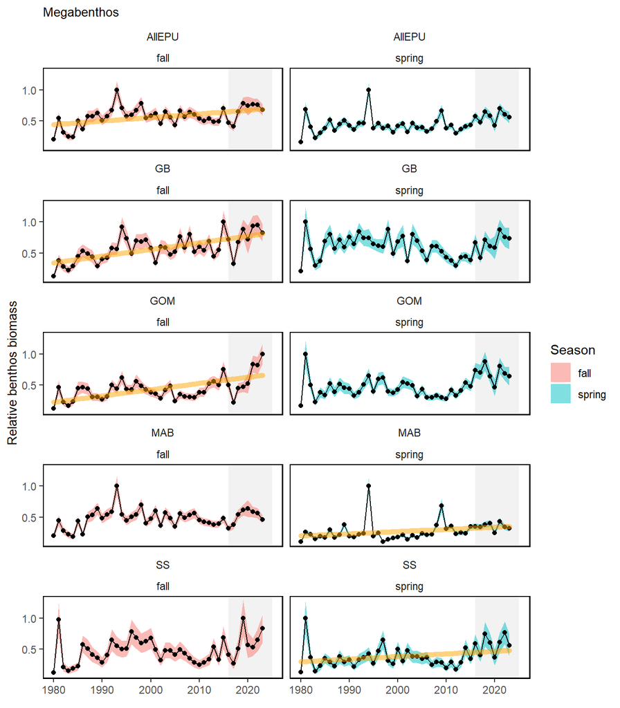

```r
    fix<- splitoutput |>
      dplyr::filter(Data %in% c("megabenthos"),
                    Region %in% filterEPUs) |>
      dplyr::group_by(Region, Season) |>
      dplyr::summarise(max = max(Estimate))

    p <- splitoutput |>
      dplyr::filter(Data %in% c("megabenthos"),
                    Region %in% filterEPUs) |>
      dplyr::group_by(Region, Season) |>
      dplyr::left_join(fix) |>
      dplyr::mutate(#Value = Value/resca,
        Mean = as.numeric(Estimate),
        SE = Std..Error.for.Estimate,
        Mean = Mean/max,
        SE = SE/max,
        Upper = Mean + SE,
        Lower = Mean - SE) |>
      ggplot2::ggplot(ggplot2::aes(x = Time, y = Mean, group = Season))+
      ggplot2::annotate("rect", fill = setup$shade.fill, alpha = setup$shade.alpha,
                        xmin = setup$x.shade.min , xmax = setup$x.shade.max,
                        ymin = -Inf, ymax = Inf) +
      ggplot2::geom_ribbon(ggplot2::aes(ymin = Lower, ymax = Upper, fill = Season), alpha = 0.5)+
      ggplot2::geom_point()+
      ggplot2::geom_line()+
      ggplot2::ggtitle("Megabenthos")+
      ggplot2::ylab(expression("Relative benthos biomass"))+
      ggplot2::xlab(ggplot2::element_blank())+
      ggplot2::facet_wrap(Region~Season, ncol = 2)+
      ecodata::geom_gls()+
      ecodata::theme_ts()+
      ecodata::theme_facet()+
      ecodata::theme_title()

    p
```

Trend comparisons by season, any difference macro and megabenthos?

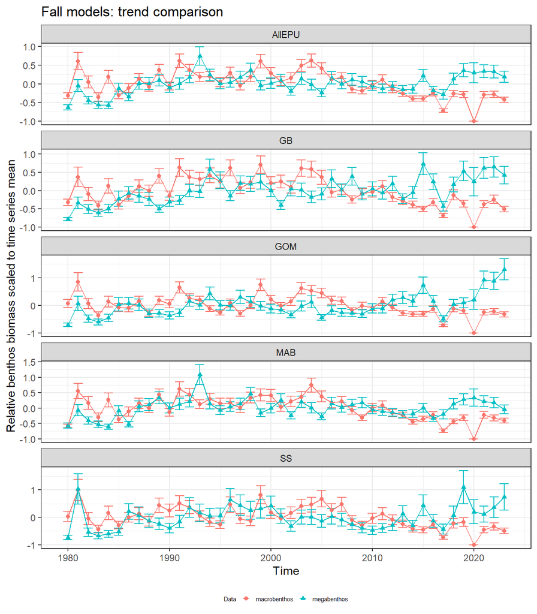

```r
ggplot(benthostsmean |> filter(Season =="fall"),
       aes(x=Time, y=((Estimate-fmean)/fmean), colour=Data)) +
  geom_errorbar(aes(ymin=(Estimate+Std..Error.for.Estimate - fmean)/fmean,
                    ymax=(Estimate-Std..Error.for.Estimate - fmean)/fmean))+
  geom_point(aes(shape=Data))+
  geom_line()+
  #acet_wrap(~fct_relevel(Type, "Ecoregion", "Bluefish"), scales = "free_y") +
  facet_wrap(~Region, scales = "free_y", ncol = 1) +
  #scale_y_continuous(labels=function(x)round(x/foragemax, digits = 2))+
  ylab("Relative benthos biomass scaled to time series mean")  +
  ggtitle("Fall models: trend comparison") +
  theme(#legend.position = c(1, 0),
        #legend.justification = c(1, 0)
        legend.position = "bottom",
        legend.text = element_text(size=rel(0.5)),
        legend.key.size = unit(0.5, 'lines'),
        legend.title = element_text(size=rel(0.5)))
```

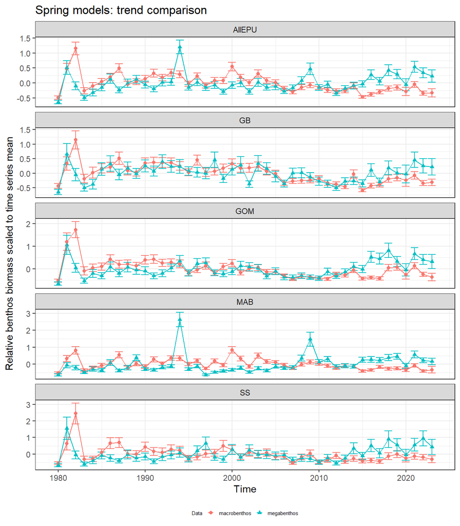

```r
ggplot(benthostsmean |> filter(Season =="spring"),
       aes(x=Time, y=((Estimate-fmean)/fmean), colour=Data)) +
  geom_errorbar(aes(ymin=(Estimate+Std..Error.for.Estimate - fmean)/fmean,
                    ymax=(Estimate-Std..Error.for.Estimate - fmean)/fmean))+
  geom_point(aes(shape=Data))+
  geom_line()+
  #acet_wrap(~fct_relevel(Type, "Ecoregion", "Bluefish"), scales = "free_y") +
  facet_wrap(~Region, scales = "free_y", ncol = 1) +
  #scale_y_continuous(labels=function(x)round(x/foragemax, digits = 2))+
  ylab("Relative benthos biomass scaled to time series mean")  +
  ggtitle("Spring models: trend comparison") +
  theme(#legend.position = c(1, 0),
        #legend.justification = c(1, 0)
        legend.position = "bottom",
        legend.text = element_text(size=rel(0.5)),
        legend.key.size = unit(0.5, 'lines'),
        legend.title = element_text(size=rel(0.5)))
```

Scale comparisons by season, any difference macro and megabenthos? Yes, way more macrobenthos, as expected.

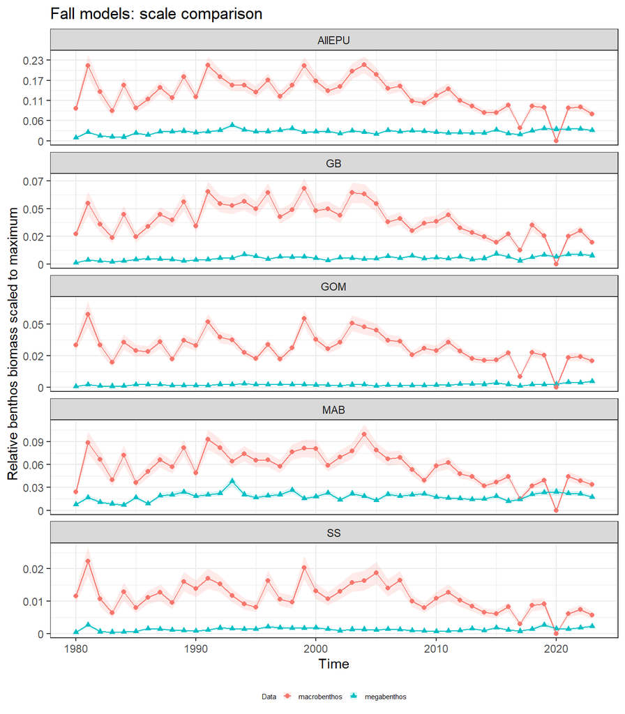

```r
ggplot(splitoutput |> filter(Season =="fall"),
       aes(x=Time, y=Estimate, colour=Data)) +
  #geom_errorbar(aes(ymin=Estimate+Std..Error.for.Estimate, ymax=Estimate-Std..Error.for.Estimate))+
  geom_ribbon(aes(ymin=Estimate+Std..Error.for.Estimate, ymax=Estimate-Std..Error.for.Estimate, fill=Data), linetype = 0, alpha = 0.15)+
  geom_point(aes(shape=Data))+
  geom_line()+
  #acet_wrap(~fct_relevel(Type, "Ecoregion", "Bluefish"), scales = "free_y") +
  facet_wrap(~Region, scales = "free_y", ncol = 1) +
  scale_y_continuous(labels=function(x)round(x/benthosmax, digits = 2))+
  ylab("Relative benthos biomass scaled to maximum")  +
  ggtitle("Fall models: scale comparison")+
  theme(#legend.position = c(1, 0),
        #legend.justification = c(1, 0)
        legend.position = "bottom",
        legend.text = element_text(size=rel(0.5)),
        legend.key.size = unit(0.5, 'lines'),
        legend.title = element_text(size=rel(0.5)))
```

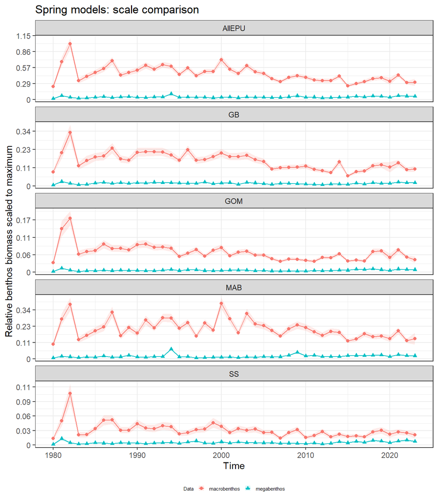

```r
ggplot(splitoutput |> filter(Season =="spring"),
       aes(x=Time, y=Estimate, colour=Data)) +
  #geom_errorbar(aes(ymin=Estimate+Std..Error.for.Estimate, ymax=Estimate-Std..Error.for.Estimate))+
  geom_ribbon(aes(ymin=Estimate+Std..Error.for.Estimate, ymax=Estimate-Std..Error.for.Estimate, fill=Data), linetype = 0, alpha = 0.15)+
  geom_point(aes(shape=Data))+
  geom_line()+
  #acet_wrap(~fct_relevel(Type, "Ecoregion", "Bluefish"), scales = "free_y") +
  facet_wrap(~Region, scales = "free_y", ncol = 1) +
  scale_y_continuous(labels=function(x)round(x/benthosmax, digits = 2))+
  ylab("Relative benthos biomass scaled to maximum")  +
  ggtitle("Spring models: scale comparison")+
  theme(#legend.position = c(1, 0),
        #legend.justification = c(1, 0)
        legend.position = "bottom",
        legend.text = element_text(size=rel(0.5)),
        legend.key.size = unit(0.5, 'lines'),
        legend.title = element_text(size=rel(0.5)))
```

# Center of gravity exploration

Has benthos shifted along the coast?

```r
library(FishStatsUtils)

getcogVAST <- function(d.name){

  fit <- VAST::reload_model(readRDS(paste0(d.name,"/fit.rds")))

  dir.create(paste0(d.name,"/test"))

  cogout <- FishStatsUtils::plot_range_index(Sdreport = fit$parameter_estimates$SD,
                                             Report = fit$Report,
                                             TmbData = fit$data_list,
                                             year_labels = as.numeric(fit$year_labels),
                                             years_to_plot = fit$years_to_plot,
                                             Znames = colnames(fit$data_list$Z_xm))

  saveRDS(cogout, here::here("benthos/pyindex/macrobenthos_spring_500_cov/cogout.rds"))



}

purrr::map(moddirs[3], getcogVAST)
```

Center of gravity plots with `ecodata` trends

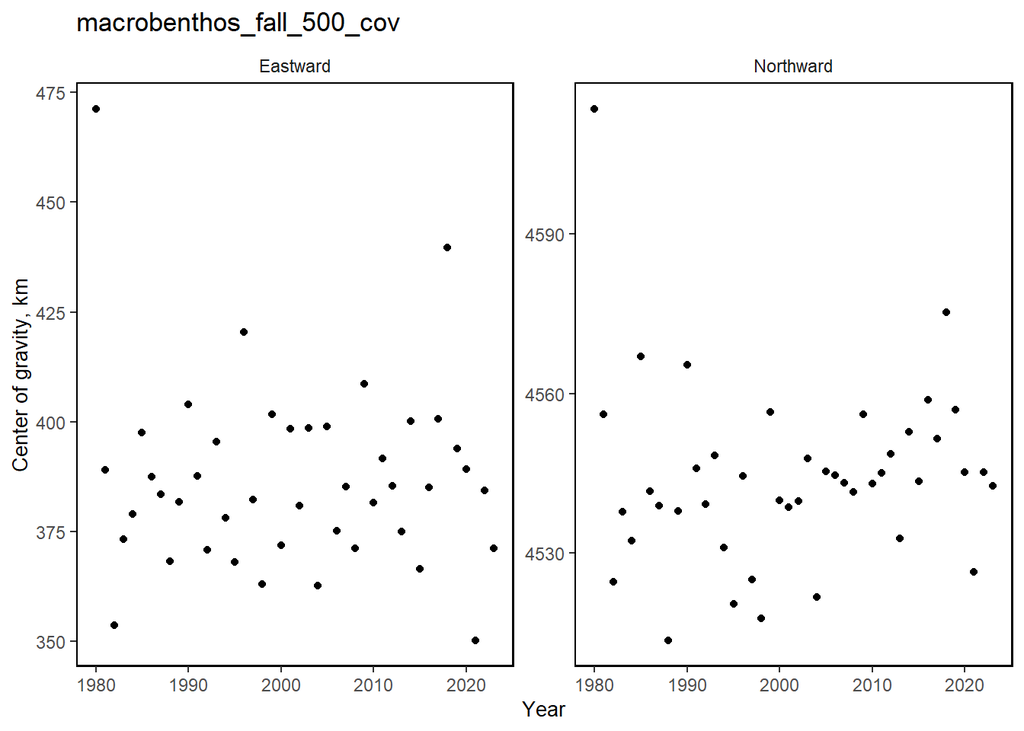

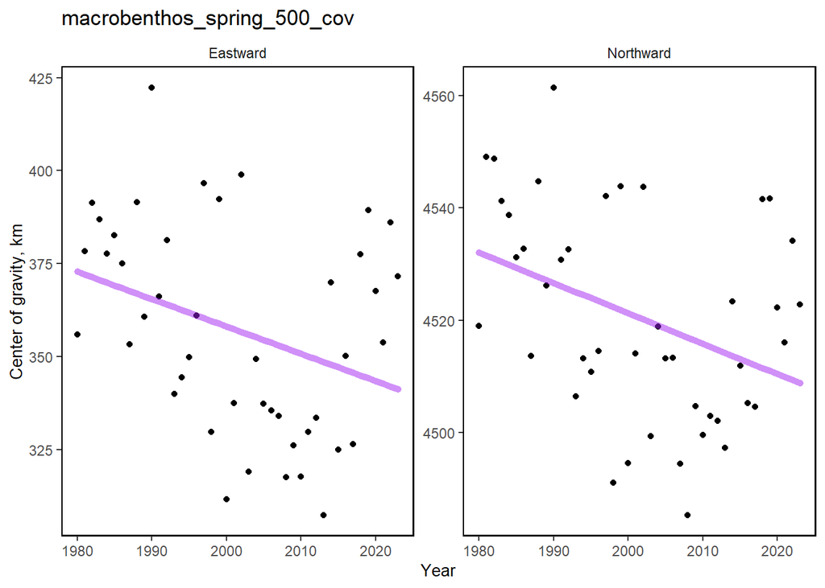

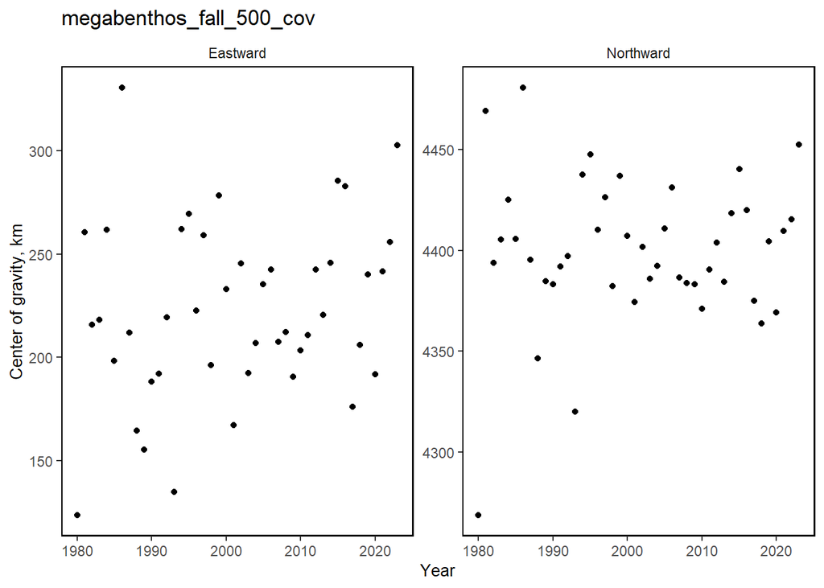

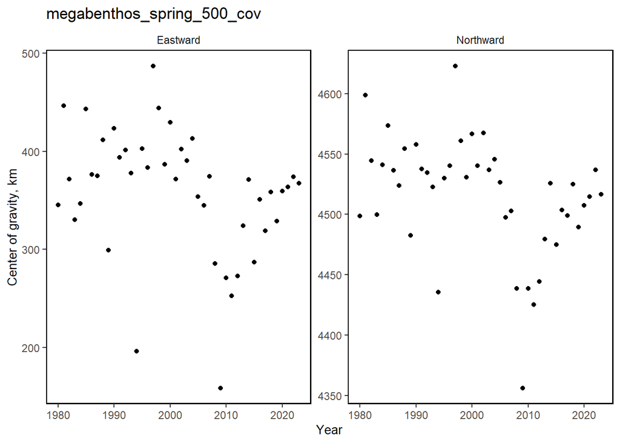

```r
plotcog <- function(d.name){

  cogout <- readRDS(paste0(d.name,"/cogout.rds"))
  modpath <- unlist(str_split(d.name, pattern = "/"))
  modname <- modpath[length(modpath)]

  cogdat <- as.data.frame(cogout$COG_Table) |>
    dplyr::mutate(direction = ifelse(m==1, "Eastward", "Northward"))

  ggplot2::ggplot(cogdat, ggplot2::aes(x = Year, y = COG_hat)) +
    ggplot2::geom_point() +
    ecodata::geom_gls() +
    ggplot2::labs(y = "Center of gravity, km") +
    ggplot2::facet_wrap(~direction, scales = "free_y") +
    ecodata::theme_facet()+
    ggplot2::ggtitle(modname)
}

purrr::map(moddirs23, plotcog)
```

Density maps

```r
for(d.name in moddirs23){

  modpath <- unlist(str_split(d.name, pattern = "/"))
  modname <- modpath[length(modpath)]

  cat(modname, "\n")
  cat(paste0("![](",d.name, "/ln_density-predicted.png)"))
  cat("\n\n")

}
```

macrobenthos_fall_500_cov

[figure not shown]

macrobenthos_spring_500_cov

[figure not shown]

megabenthos_fall_500_cov

[figure not shown]

megabenthos_spring_500_cov

[figure not shown]

# What prey are in the raw input data?

## Macrobenthos composition over time in stomachs

NEFSC data only

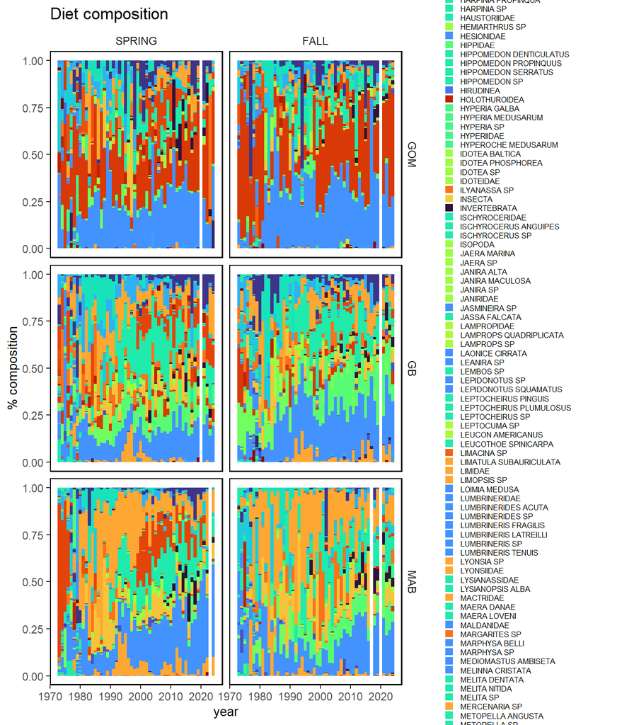

```r
macrobenall_stn <- readRDS(here::here("benthos/fhdata/macrobenall_stn.rds"))

 MAB <- data.frame(stratum = c(1010:1080, 1100:1120, 1600:1750, 3010:3450, 3470, 3500, 3510),
                      EPU = "MAB")

 GB <- data.frame(stratum = c(1090, 1130:1210, 1230, 1250, 3460, 3480, 3490, 3520:3550),
                  EPU = "GB")

 GOM <- data.frame(stratum = c(1220, 1240, 1260:1290, 1360:1400, 3560:3830),
                   EPU = "GOM")

EPUlook <- dplyr::bind_rows(MAB, GB, GOM)

# object is called prey
load(here::here("benthos/data/prey.RData")) #original mappings from June 2023

addtomacro <- prey |>
  dplyr::filter(RPATH == "Megabenthos") |>
  dplyr::filter(PYNAM %in% c("ALBUNEA PARETII", "EMERITA TALPOIDA", "RANILIA MURICATA", "HIPPIDAE"))

megaben <- prey |>
  dplyr::filter(RPATH == "Megabenthos") |>
  dplyr::filter(!PYNAM %in% c("ALBUNEA PARETII", "EMERITA TALPOIDA", "RANILIA MURICATA", "HIPPIDAE"))

macroben <- prey |>
  dplyr::filter(RPATH == "Macrobenthos") |>
  dplyr::filter(!PYNAM %in% c("PECTINIDAE", "PECTINIDAE SHELL", "PECTINIDAE VISCERA")) |>
  dplyr::bind_rows(addtomacro)

macroben.analcoll <- macroben |>
  dplyr::select(PYNAM, PYCOMNAM, AnalSci, AnalCom, CollSci, Collcom)

collcolors <- data.frame(prey = unique(macroben.analcoll$Collcom),
                        #preycol = colors()[seq(1, length(colors()), 15)])
                        preycol = viridis::turbo(length(unique(macroben.analcoll$Collcom))))


macrobensppwt <- macrobenall_stn %>%
  dplyr::left_join(EPUlook) %>%
  dplyr::filter(macrobenthos=="macroben",
                !is.na(EPU),
                !is.na(season_ng)) %>%
  dplyr::group_by(year, season_ng, EPU, macrobenpynam) %>%
  dplyr::summarise(pysum = sum(macrobenpywt)) %>%
  dplyr::mutate(pyprop = pysum / sum(pysum)) %>%
  dplyr::ungroup() %>%
  dplyr::left_join(macroben.analcoll, by =  dplyr::join_by(macrobenpynam == PYNAM)) |>
  dplyr::left_join(collcolors, by =  dplyr::join_by(Collcom == prey))

preycols <- macrobensppwt$preycol
names(preycols) <- as.factor(macrobensppwt$macrobenpynam)

preyaggcols <- macrobensppwt$preycol
names(preyaggcols) <- as.factor(macrobensppwt$Collcom)


top20spp <- macrobensppwt |>
  dplyr::group_by(season_ng, EPU, Collcom) |>
  dplyr::summarise(meanprop = mean(pyprop, na.rm = TRUE),
                   maxprop = max(pyprop, na.rm = TRUE)) |>
  dplyr::ungroup() |>
  dplyr::arrange(EPU, season_ng, desc(meanprop))

plotDietCompBar <- function(dat, metric, catname, plotcol, title=NULL){   #defines the name of the function and the requied inputs

dat %>%
  filter(!is.na(.data[[metric]])) %>%          #take out the NA values (literally "not is NA")
  ggplot(aes(x=year, y=.data[[metric]], fill=.data[[catname]])) +     #year on x axis, %diet comp on y
  geom_bar(width = 1, stat = "identity", position="fill") +    #stacked bar chart
  scale_fill_manual(values=plotcol) +         #custom colors
  ecodata::theme_facet() +                    #simplify
  facet_grid(fct_relevel(EPU,  "GOM", "GB", "MAB")~
               fct_relevel(season_ng, "SPRING", "FALL")) + #separate by ordered epu and season
  labs(y = "% composition",              #add sensible labels
       title = title)

}

addSmallLegend <- function(myPlot, pointSize = 2, textSize = 6, spaceLegend = 0.5) {
    myPlot +
        guides(shape = guide_legend(override.aes = list(size = pointSize)),
               color = guide_legend(override.aes = list(size = pointSize)),
               fill = guide_legend(ncol = 1)) +
        theme(legend.title = element_text(size = textSize),
              legend.text  = element_text(size = textSize),
              legend.key.size = unit(spaceLegend, "lines"))
}

pall <- plotDietCompBar(dat=macrobensppwt,
                          metric="pysum",
                        catname="macrobenpynam",
                        plotcol=preycols,
                          title="Diet composition")

pcat <- plotDietCompBar(dat=macrobensppwt,
                          metric="pysum",
                        catname="Collcom",
                        plotcol=preyaggcols,
                          title="Diet composition")

addSmallLegend(pall)
```

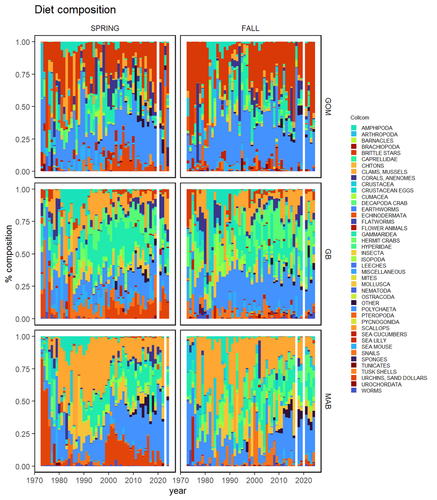

```r
addSmallLegend(pcat)
```

Collcom trends by EPU

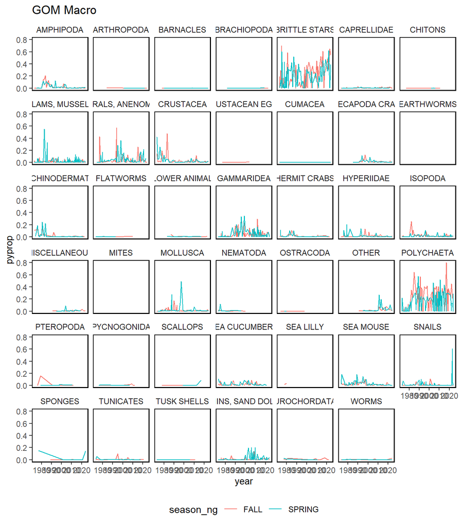

```r
macrobensppwt |>
  dplyr::filter(EPU=="GOM") |>
  ggplot2::ggplot(ggplot2::aes(x=year, y=pyprop, colour = season_ng)) +
  ggplot2::geom_line() +
  ecodata::theme_facet() +
  ggplot2::facet_wrap(~Collcom) +
  ggplot2::ggtitle("GOM Macro") +
  ggplot2::theme(legend.position = "bottom")
```

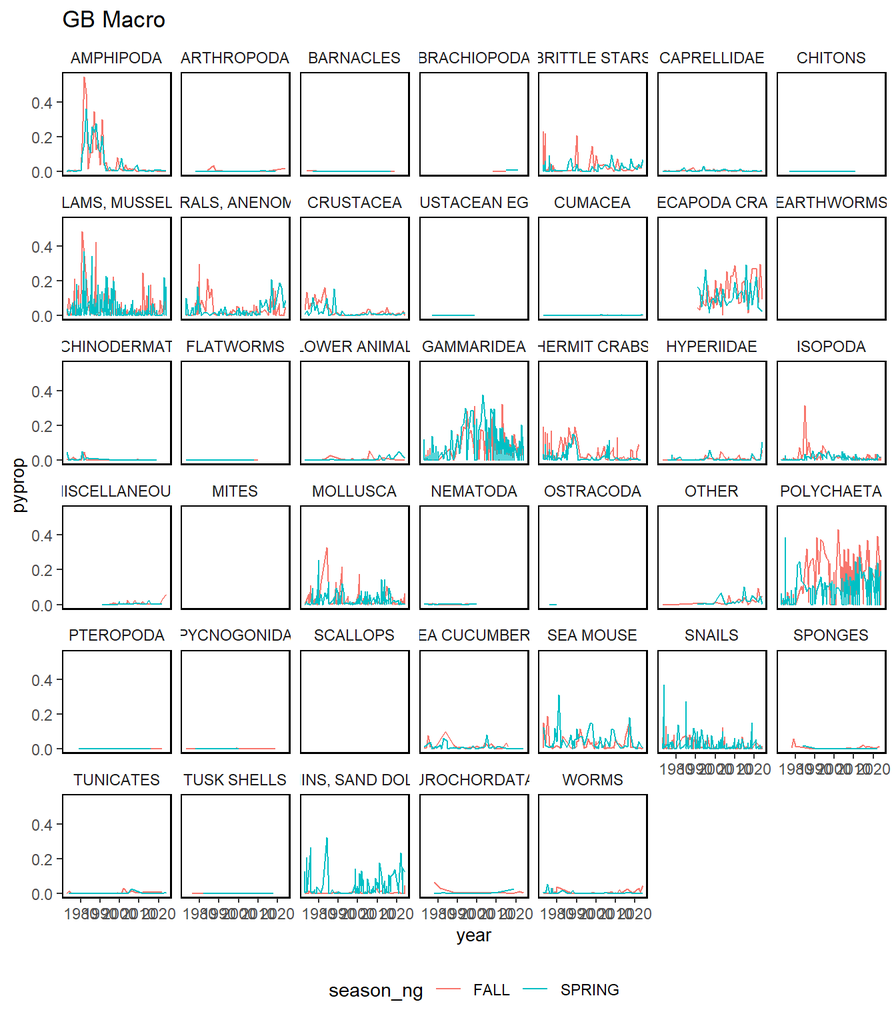

```r
macrobensppwt |>
  dplyr::filter(EPU=="GB") |>
  ggplot2::ggplot(ggplot2::aes(x=year, y=pyprop, colour = season_ng)) +
  ggplot2::geom_line() +
  ecodata::theme_facet() +
  ggplot2::facet_wrap(~Collcom) +
  ggplot2::ggtitle("GB Macro")+
  ggplot2::theme(legend.position = "bottom")
```

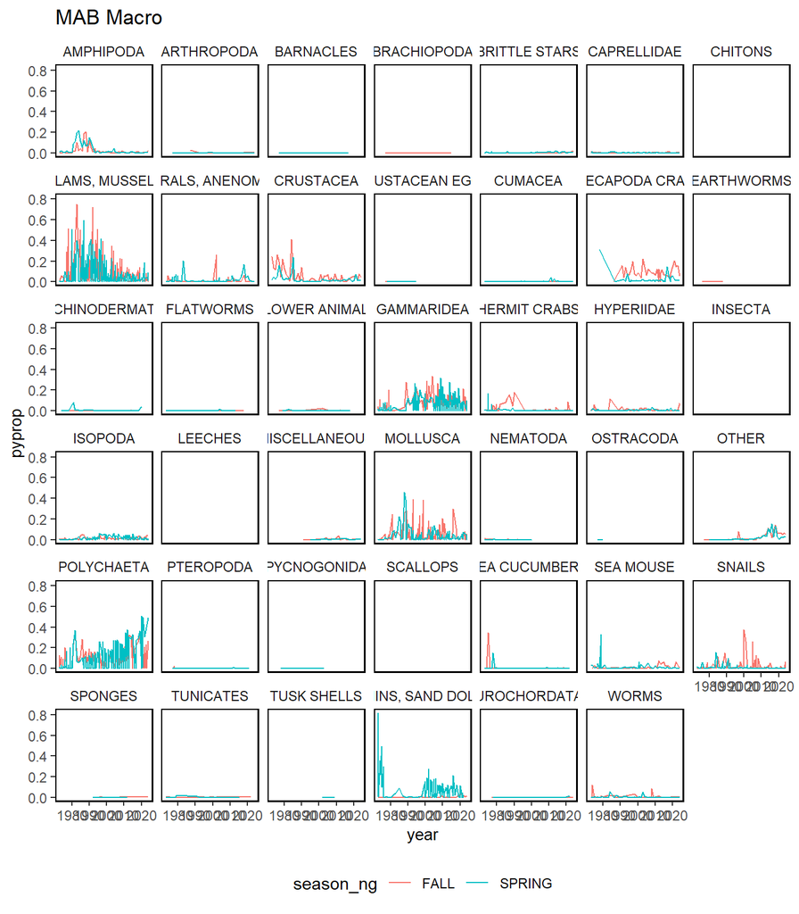

```r
macrobensppwt |>
  dplyr::filter(EPU=="MAB") |>
  ggplot2::ggplot(ggplot2::aes(x=year, y=pyprop, colour = season_ng)) +
  ggplot2::geom_line() +
  ecodata::theme_facet() +
  ggplot2::facet_wrap(~Collcom) +
  ggplot2::ggtitle("MAB Macro")+
  ggplot2::theme(legend.position = "bottom")
```

## Megabenthos composition over time in stomachs

NEFSC data only

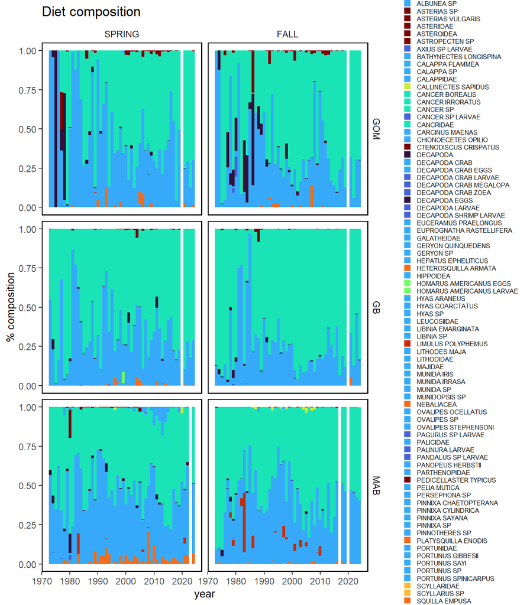

```r
megabenall_stn <- readRDS(here::here("benthos/fhdata/megabenall_stn.rds"))


megaben.analcoll <- megaben |>
  dplyr::select(PYNAM, PYCOMNAM, AnalSci, AnalCom, CollSci, Collcom)

collcolors <- data.frame(prey = unique(megaben.analcoll$Collcom),
                        #preycol = colors()[seq(1, length(colors()), 15)])
                        preycol = viridis::turbo(length(unique(megaben.analcoll$Collcom))))


megabensppwt <- megabenall_stn %>%
  dplyr::left_join(EPUlook) %>%
  dplyr::filter(megabenthos=="megaben",
                !is.na(EPU),
                !is.na(season_ng)) %>%
  dplyr::group_by(year, season_ng, EPU, megabenpynam) %>%
  dplyr::summarise(pysum = sum(megabenpywt)) %>%
  dplyr::mutate(pyprop = pysum / sum(pysum)) %>%
  dplyr::ungroup() %>%
  dplyr::left_join(megaben.analcoll, by =  dplyr::join_by(megabenpynam == PYNAM)) |>
  dplyr::left_join(collcolors, by =  dplyr::join_by(Collcom == prey))

preycols <- megabensppwt$preycol
names(preycols) <- as.factor(megabensppwt$megabenpynam)

preyaggcols <- megabensppwt$preycol
names(preyaggcols) <- as.factor(megabensppwt$Collcom)


top20spp <- megabensppwt |>
  dplyr::group_by(season_ng, EPU, Collcom) |>
  dplyr::summarise(meanprop = mean(pyprop, na.rm = TRUE),
                   maxprop = max(pyprop, na.rm = TRUE)) |>
  dplyr::ungroup() |>
  dplyr::arrange(EPU, season_ng, desc(meanprop))


pall <- plotDietCompBar(dat=megabensppwt,
                          metric="pysum",
                        catname="megabenpynam",
                        plotcol=preycols,
                          title="Diet composition")

pcat <- plotDietCompBar(dat=megabensppwt,
                          metric="pysum",
                        catname="Collcom",
                        plotcol=preyaggcols,
                          title="Diet composition")

addSmallLegend(pall)
```

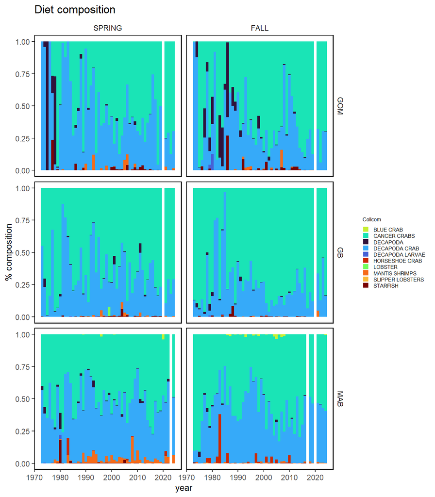

```r
addSmallLegend(pcat)
```

Collcom trends by EPU

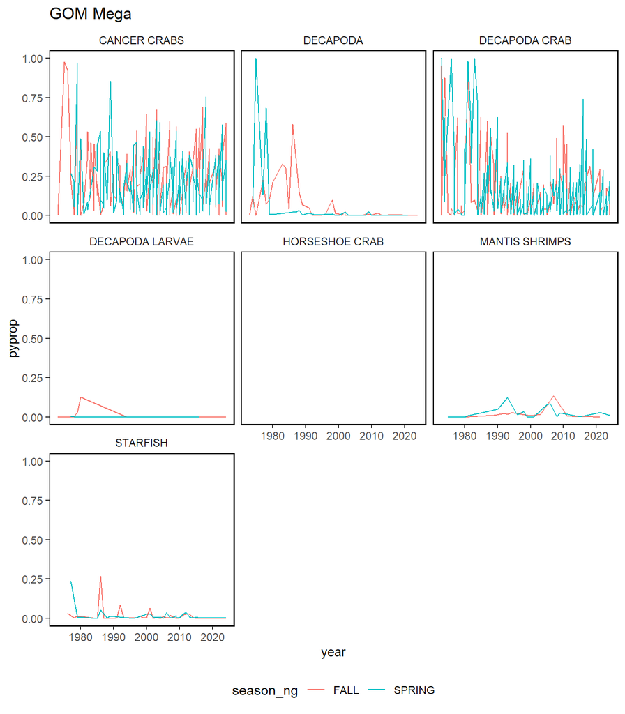

```r
megabensppwt |>
  dplyr::filter(EPU=="GOM") |>
  ggplot2::ggplot(ggplot2::aes(x=year, y=pyprop, colour = season_ng)) +
  ggplot2::geom_line() +
  ecodata::theme_facet() +
  ggplot2::facet_wrap(~Collcom) +
  ggplot2::ggtitle("GOM Mega") +
  ggplot2::theme(legend.position = "bottom")
```